# Step 1. Import the necessary libraries

```python
import numpy as np #importing Numpy package
import pandas as pd #importing pandas package
from matplotlib import pyplot as plt #importing Matplotlib package
import seaborn as sns #importing Seaborn package
```

# Step2. Read the data as a data frame

```python
data_Insurance = pd.read_csv("insurance.csv")
```

```python
data_Insurance.head()
```

|  | age | sex | bmi | children | smoker | region | charges |
| --- | --- | --- | --- | --- | --- | --- | --- |
| 0 | 19 | female | 27.900 | 0 | yes | southwest | 16884.92400 |
| 1 | 18 | male | 33.770 | 1 | no | southeast | 1725.55230 |
| 2 | 28 | male | 33.000 | 3 | no | southeast | 4449.46200 |
| 3 | 33 | male | 22.705 | 0 | no | northwest | 21984.47061 |
| 4 | 32 | male | 28.880 | 0 | no | northwest | 3866.85520 |

# Step3. Perform basic EDA

a) Shape of the data

```python
data_Insurance.shape
```

```
(1338, 7)
```

This is 2D data frame. It contains 1338 rows and 7 columns.

b) Data type of each attribute

```python
print('Datatypes of the columns\n'),data_Insurance.info
```

```
Datatypes of the columns
```

```
(None,
 <bound method DataFrame.info of       age     sex     bmi  children smoker     region      charges
 0      19  female  27.900         0    yes  southwest  16884.92400
 1      18    male  33.770         1     no  southeast   1725.55230
 2      28    male  33.000         3     no  southeast   4449.46200
 3      33    male  22.705         0     no  northwest  21984.47061
 4      32    male  28.880         0     no  northwest   3866.85520
 ...   ...     ...     ...       ...    ...        ...          ...
 1333   50    male  30.970         3     no  northwest  10600.54830
 1334   18  female  31.920         0     no  northeast   2205.98080
 1335   18  female  36.850         0     no  southeast   1629.83350
 1336   21  female  25.800         0     no  southwest   2007.94500
 1337   61  female  29.070         0    yes  northwest  29141.36030

 [1338 rows x 7 columns]>)
```

```python
data_Insurance.info()
```

```
<class 'pandas.core.frame.DataFrame'>
RangeIndex: 1338 entries, 0 to 1337
Data columns (total 7 columns):
 #   Column    Non-Null Count  Dtype
---  ------    --------------  -----
 0   age       1338 non-null   int64
 1   sex       1338 non-null   object
 2   bmi       1338 non-null   float64
 3   children  1338 non-null   int64
 4   smoker    1338 non-null   object
 5   region    1338 non-null   object
 6   charges   1338 non-null   float64
dtypes: float64(2), int64(2), object(3)
memory usage: 73.3+ KB
```

As per obove information Sex,Smoker and Region are non numeric that is objects. We need to convert them . Also no null value in the data set.

c) Checking the presence of missing values

```python
print ('Check if any values are NULL: ', data_Insurance.isnull().values.any())
```

```
Check if any values are NULL:  False
```

```python
data_Insurance.isnull().sum()
```

```
age         0
sex         0
bmi         0
children    0
smoker      0
region      0
charges     0
dtype: int64
```

No null value in the dataset.

d) 5 point summary of numerical attributes

```python
data_Insurance.describe()
```

|  | age | bmi | children | charges |
| --- | --- | --- | --- | --- |
| count | 1338.000000 | 1338.000000 | 1338.000000 | 1338.000000 |
| mean | 39.207025 | 30.663397 | 1.094918 | 13270.422265 |
| std | 14.049960 | 6.098187 | 1.205493 | 12110.011237 |
| min | 18.000000 | 15.960000 | 0.000000 | 1121.873900 |
| 25% | 27.000000 | 26.296250 | 0.000000 | 4740.287150 |
| 50% | 39.000000 | 30.400000 | 1.000000 | 9382.033000 |
| 75% | 51.000000 | 34.693750 | 2.000000 | 16639.912515 |
| max | 64.000000 | 53.130000 | 5.000000 | 63770.428010 |

e) Distribution of ‘bmi’, ‘age’ and ‘charges’ columns.

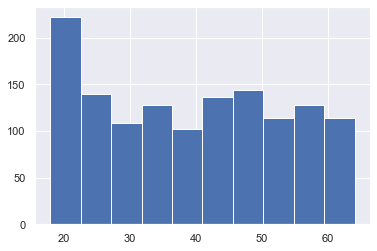

```python
data_Insurance['age'].hist()#Histogram
```

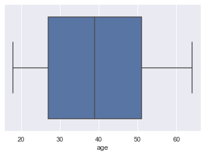

```python
sns.boxplot(data_Insurance["age"])#Boxplot
```

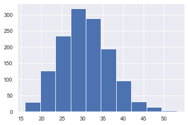

```python
data_Insurance['bmi'].hist()#Histogram
```

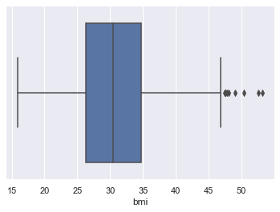

```python
sns.boxplot(data_Insurance["bmi"])#Boxplot
```

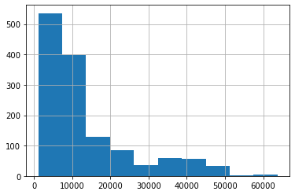

```python
data_Insurance['charges'].hist()#Histogram
```

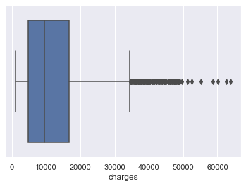

```python
sns.boxplot(data_Insurance["charges"])#Boxplot
```

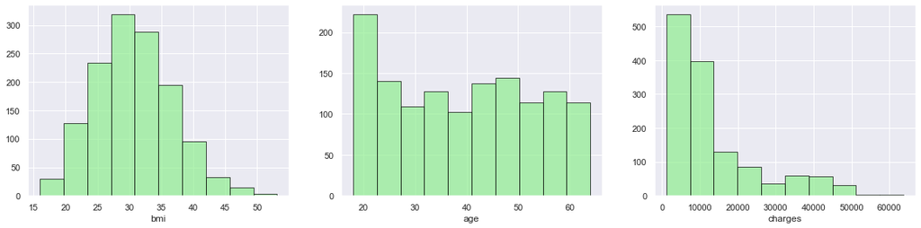

```python
plt.figure(figsize= (20,15))
plt.subplot(3,3,2)
plt.hist(data_Insurance.age, color='lightgreen', edgecolor = 'black', alpha = 0.7)
plt.xlabel('age')

plt.subplot(3,3,1)
plt.hist(data_Insurance.bmi, color='lightgreen', edgecolor = 'black', alpha = 0.7)
plt.xlabel('bmi')

plt.subplot(3,3,3)
plt.hist(data_Insurance.charges, color='lightgreen', edgecolor = 'black', alpha = 0.7)
plt.xlabel('charges')

plt.show()
```

f) Measure of skewness of ‘bmi’, ‘age’ and ‘charges’ columns

```python
data_Insurance.skew()
```

```
age         0.055673
bmi         0.284047
children    0.938380
charges     1.515880
dtype: float64
```

g) Checking the presence of outliers in ‘bmi’, ‘age’ and ‘charges columns

[output not shown]

1338 rows × 7 columns

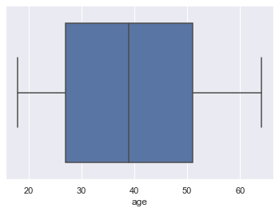

```python
#Checking the presence of outliers for age
sns.boxplot (x=insurance_z['age'])
data_Insurance[abs(insurance_z['age']) > 1.5]
```

[output not shown]

1338 rows × 7 columns

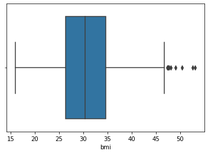

```python
#Checking the presence of outliers for bmi
sns.boxplot (x=insurance_z['bmi'], whis=1.5)
data_Insurance[abs(insurance_z['bmi']) > 1.5]
```

[output not shown]

1338 rows × 7 columns

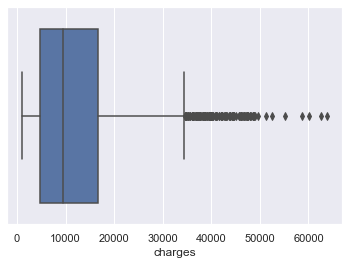

```python
#Checking the presence of outliers for charges
sns.boxplot (x=insurance_z['charges'])
data_Insurance[abs(insurance_z['charges']) > 1.5]
```

- No outlier in age attribute.
- BMI has less values which tell us very less people have BMI out the average people.
- Charges as it is highly skewed,as there are lot of extreme values. This shows that rarely people paid high charges.

g) Distribution of categorical columns (include children)

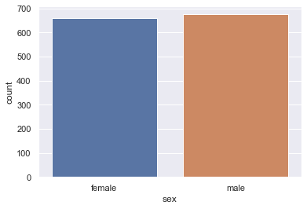

```python
sns.set (style="darkgrid")
sns.countplot(x='sex', data=data_Insurance)
```

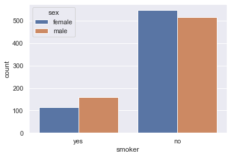

```python
sns.countplot(data_Insurance['smoker'],hue = data_Insurance['sex'])
```

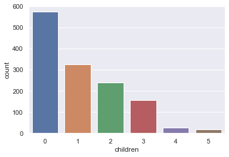

```python
sns.countplot(x='children', data=data_Insurance)
```

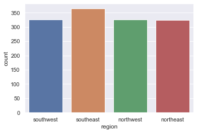

```python
sns.countplot(x='region', data=data_Insurance)
```

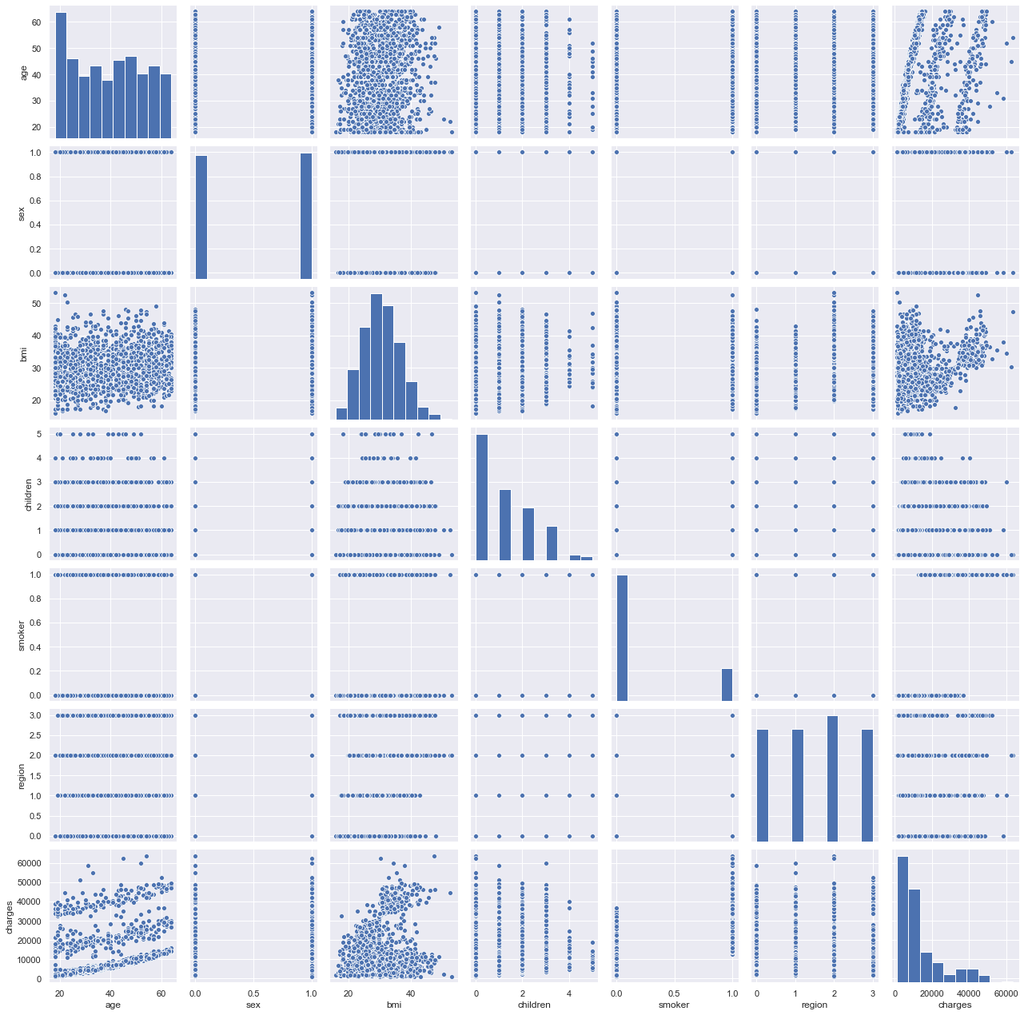

```python
#Label encoding the variables before doing a pairplot because pairplot ignores strings
insurance_encoded = copy.deepcopy(data_Insurance)
insurance_encoded.loc[:,['sex', 'smoker', 'region']] = data_Insurance.loc[:,['sex', 'smoker', 'region']].apply(LabelEncoder().fit_transform)
sns.pairplot(insurance_encoded)  #pairplot
plt.show()
```

# Step 4. Answer the following questions with statistical evidence

a) Do charges of people who smoke differ significantly from the people who don't?

```python
#First checking the number of Smokers and non smokers
data_Insurance.smoker.value_counts()
```

```
no     1064
yes     274
Name: smoker, dtype: int64
```

plotting the scatter plot for the charges for smokers and non-smokers

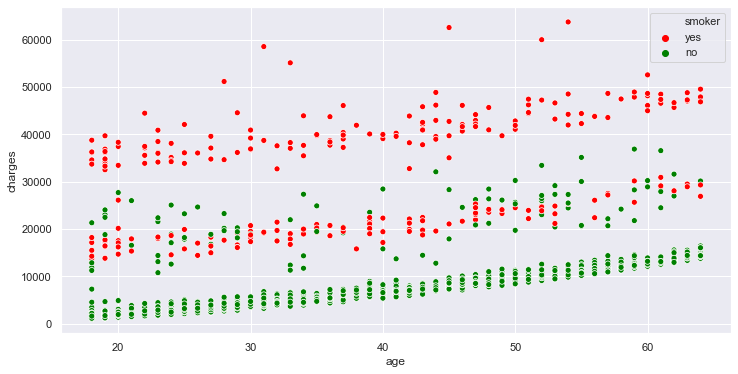

```python
plt.figure(figsize=(12,6))
sns.scatterplot (x=data_Insurance['age'], y=data_Insurance['charges'], hue=data_Insurance['smoker'],palette= ['red','green'])
```

As per above graph we can see that smokers differ significantly from the no-smokers.

```python
data_Insurance.groupby (['smoker']).count() #grouping the charges for smokers and non-smokers
```

| smoker | age | sex | bmi | children | region | charges |
| --- | --- | --- | --- | --- | --- | --- |
| no | 1064 | 1064 | 1064 | 1064 | 1064 | 1064 |
| yes | 274 | 274 | 274 | 274 | 274 | 274 |

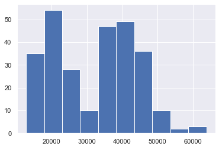

```python
# Getting the Charges for Smokers and non-Smokers by a filter
smoke_filter = data_Insurance.apply (lambda row: (row['smoker'] == 'yes'), axis=1)
charges_smoker = (data_Insurance[smoke_filter])['charges']
charges_no_smoker = (data_Insurance[~smoke_filter])['charges']

charges_smoker.hist()
```

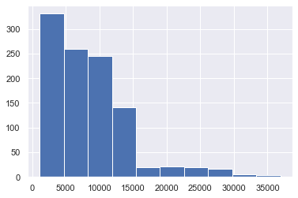

```python
charges_no_smoker.hist()
```

```python
Ho = "Charges of smoker and non-smoker are same"
Ha = "Charges of smoker and non-smoker are not the same"

x = np.array(data_Insurance[data_Insurance.smoker == 'yes'].charges)  # Selecting charges corresponding to smokers as an array
y = np.array(data_Insurance[data_Insurance.smoker == 'no'].charges) # Selecting charges corresponding to non-smokers as an array

t, p_value  = stats.ttest_ind(x,y, axis = 0)  #Performing an Independent t-test

print(p_value)
```

```
8.271435842177219e-283
```

Rejecting the null hypothesis as the p_value is lesser than 0.05. So, the Null Hypothesis is Rejected and Alternative Hypothesis is Accepted. It tells us that the paid charges by the smokers and non-smokers is significantly different. So that Smokers pays higher charges than the non-smokers.

b) Does bmi of males differ significantly from that of females?

```python
data_Insurance.sex.value_counts() #Male and females count
```

```
male      676
female    662
Name: sex, dtype: int64
```

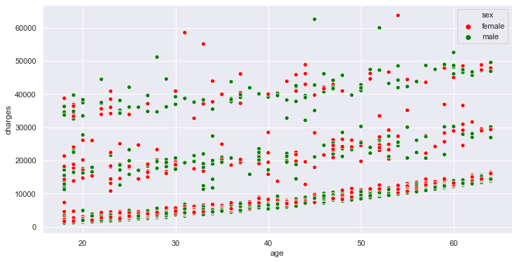

```python
plt.figure(figsize=(12,6))
sns.scatterplot(data_Insurance.age, data_Insurance.charges,hue=data_Insurance.sex,palette= ['red','green'] )
plt.show()
```

```python
###### Check dependency of bmi on gender.#Performing an Independent t-test
Ho = "Gender has no impact on bmi"
Ha = "Gender has an impact on bmi"

x = np.array(data_Insurance[data_Insurance.sex == 'male'].bmi)
y = np.array(data_Insurance[data_Insurance.sex == 'female'].bmi)

t, p_value  = stats.ttest_ind(x,y, axis = 0)

print(p_value)
```

```
0.08997637178984932
```

Accepting nullhypothesis as pvalue >0.05. Gender has no effect on BMI. BMI for male do not differ significantly than from female

c) Is the proportion of smokers significantly different in different genders?

```python
# We will perform Chi_square test to check the proportion of smokers differs as per gender.
Ho = "Gender has no effect on smoking habits"
Ha = "Gender has an effect on smoking habits"

crosstab = pd.crosstab(data_Insurance['sex'],data_Insurance['smoker'])
chi, p_value, dof, expected =  stats.chi2_contingency(crosstab)
print(p_value)
```

```
0.006548143503580696
```

Here, p_value 0.007 < 0.05, level of significance error So, the Null Hypothesis is Rejected and Alternative Hypothesis is Accepted Significant difference between the proportions of smokers in different genders

d) Is the distribution of bmi across women with no children, one child and two children, the same ?

```python
Ho = "No. of children has no effect on bmi"
Ha = "No. of children has an effect on bmi"

female_df = copy.deepcopy(data_Insurance[data_Insurance['sex'] == 'female'])

zero = female_df[female_df.children == 0]['bmi']
one = female_df[female_df.children == 1]['bmi']
two = female_df[female_df.children == 2]['bmi']

f_stat, p_value = stats.f_oneway(zero,one,two)
print(p_value)
```

```
0.7158579926754841
```

Accepting the null hypothesis.As,it tells us the number of children is not effecting any difference in women's BMI value.